# Supply Chain Analytics – Demand Forecasting & Anomaly Detection.

## Day 8 - Advanced Forecasting ARIMA.

```python
#import required libraries & LOAD FEATURE-ENGINEERED DATA

import pandas as pd
import numpy as np
import matplotlib.pyplot as plt
import seaborn as sns

from statsmodels.tsa.arima.model import ARIMA
from sklearn.metrics import mean_absolute_error, mean_squared_error

import warnings
warnings.filterwarnings("ignore")


# Load Feature-Engineered Dataset

file_path = r"C:\Users\LENOVO\Desktop\Supply-Chain-Demand-Forecasting-Anomaly-Detection\data\processed\supply_chain_feature_engineered.csv"

df = pd.read_csv(file_path)

# Convert Date column to datetime
df["Date"] = pd.to_datetime(df["Date"])

# Sort data chronologically
df = df.sort_values("Date").reset_index(drop=True)

# Basic Information

print("Feature-Engineered Dataset Loaded Successfully")
print("=" * 55)

print("Shape :", df.shape)

print("\nDate Range:")
print("Start :", df["Date"].min())
print("End   :", df["Date"].max())

print("\nMissing Values :", df.isnull().sum().sum())
print("Duplicate Rows :", df.duplicated().sum())

print("\nColumns :", df.columns.tolist())
```

[output not shown]

```python
# CELL 2 — CREATE DAILY DEMAND TIME SERIES

daily_demand = (
    df.groupby("Date")["Units_Sold"]
      .sum()
      .reset_index(name="Total_Demand")
      .sort_values("Date")
      .reset_index(drop=True)
)

print("Daily Demand Time Series Created Successfully")
print("=" * 55)

print("Shape :", daily_demand.shape)

print("\nDate Range:")
print("Start :", daily_demand["Date"].min())
print("End   :", daily_demand["Date"].max())

print("\nDaily Demand Summary:")
print(daily_demand["Total_Demand"].describe())

print("\nSample:")
display(daily_demand.head())
```

```
Daily Demand Time Series Created Successfully
=======================================================
Shape : (335, 2)

Date Range:
Start : 2024-01-31 00:00:00
End   : 2024-12-30 00:00:00

Daily Demand Summary:
count     335.000000
mean     4953.794030
std      1883.471423
min      2294.000000
25%      3139.000000
50%      4665.000000
75%      6899.500000
max      7702.000000
Name: Total_Demand, dtype: float64

Sample:
```

|  | Date | Total_Demand |
| --- | --- | --- |
| 0 | 2024-01-31 | 6223 |
| 1 | 2024-02-01 | 6346 |
| 2 | 2024-02-02 | 6270 |
| 3 | 2024-02-03 | 6434 |
| 4 | 2024-02-04 | 6335 |

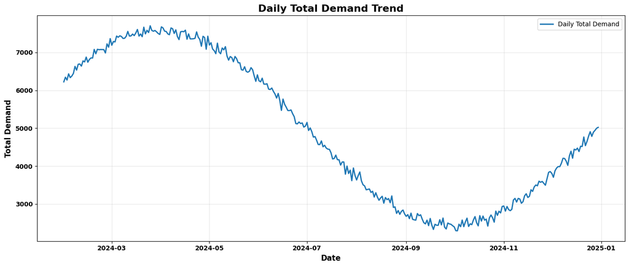

```python
# CELL 3 — DAILY DEMAND TREND VISUALIZATION

plt.figure(figsize=(14, 6))

plt.plot(
    daily_demand["Date"],
    daily_demand["Total_Demand"],
    linewidth=2,
    label="Daily Total Demand"
)

plt.title("Daily Total Demand Trend", fontsize=16, fontweight="bold")
plt.xlabel("Date", fontsize=12, fontweight="bold")
plt.ylabel("Total Demand", fontsize=12, fontweight="bold")

plt.xticks(fontweight="bold")
plt.yticks(fontweight="bold")

plt.grid(alpha=0.3)
plt.legend()

plt.tight_layout()
plt.show()
```

```python
# CELL 4 — CHRONOLOGICAL TRAIN-TEST SPLI

split_index = int(len(daily_demand) * 0.80)

train = daily_demand.iloc[:split_index].copy()
test = daily_demand.iloc[split_index:].copy()

print("Chronological Train-Test Split Completed")
print("=" * 55)

print("Train Shape :", train.shape)
print("Test Shape  :", test.shape)

print("\nTrain Date Range:")
print("Start :", train["Date"].min())
print("End   :", train["Date"].max())

print("\nTest Date Range:")
print("Start :", test["Date"].min())
print("End   :", test["Date"].max())

print("\nDate Overlap Check :",
      len(set(train["Date"]).intersection(set(test["Date"]))))
```

```
Chronological Train-Test Split Completed
=======================================================
Train Shape : (268, 2)
Test Shape  : (67, 2)

Train Date Range:
Start : 2024-01-31 00:00:00
End   : 2024-10-24 00:00:00

Test Date Range:
Start : 2024-10-25 00:00:00
End   : 2024-12-30 00:00:00

Date Overlap Check : 0
```

```python
# CELL 5 — ARIMA MODEL TRAINING

# Prepare training series
train_series = train["Total_Demand"].astype(float)

# Fit ARIMA model
arima_model = ARIMA(
    train_series,
    order=(1, 1, 1)
)

arima_result = arima_model.fit()

print("ARIMA Model Trained Successfully")
print("=" * 55)

print("Model : ARIMA(1,1,1)")
print("Training Observations :", len(train_series))

print("\nModel Summary:")
print(arima_result.summary())
```

```
ARIMA Model Trained Successfully
=======================================================
Model : ARIMA(1,1,1)
Training Observations : 268

Model Summary:
                               SARIMAX Results
==============================================================================
Dep. Variable:           Total_Demand   No. Observations:                  268
Model:                 ARIMA(1, 1, 1)   Log Likelihood               -1640.132
Date:                Sun, 16 Aug 2026   AIC                           3286.264
Time:                        10:30:51   BIC                           3297.026
Sample:                             0   HQIC                          3290.587
                                - 268
Covariance Type:                  opg
==============================================================================
                 coef    std err          z      P>|z|      [0.025      0.975]
------------------------------------------------------------------------------
ar.L1         -0.3112      0.131     -2.382      0.017      -0.567      -0.055
ma.L1         -0.1775      0.133     -1.334      0.182      -0.438       0.083
sigma2      1.262e+04   1185.100     10.653      0.000    1.03e+04    1.49e+04
===================================================================================
Ljung-Box (L1) (Q):                   0.61   Jarque-Bera (JB):                 0.84
Prob(Q):                              0.43   Prob(JB):                         0.66
Heteroskedasticity (H):               1.17   Skew:                             0.05
Prob(H) (two-sided):                  0.45   Kurtosis:                         2.75
===================================================================================

Warnings:
[1] Covariance matrix calculated using the outer product of gradients (complex-step).
```

```python
# CELL 6 — ARIMA TEST FORECAST

forecast_steps = len(test)

arima_forecast = arima_result.forecast(
    steps=forecast_steps
)

arima_forecast = np.asarray(arima_forecast)

print("ARIMA Forecast Generated Successfully")
print("=" * 55)

print("Forecast Horizon :", len(arima_forecast))
print("Expected Horizon :", len(test))

print("\nForecast Sample:")
print(arima_forecast[:10])
```

```
ARIMA Forecast Generated Successfully
=======================================================
Forecast Horizon : 67
Expected Horizon : 67

Forecast Sample:
[2658.73201554 2674.99682966 2669.93552529 2671.51050806 2671.02040303
 2671.1729145  2671.1254558  2671.14022405 2671.13562845 2671.13705851]
```

```python
# CELL 7 — CREATE ARIMA FORECAST DATAFRAME

arima_forecast_df = test[["Date", "Total_Demand"]].copy()

arima_forecast_df["ARIMA_Forecast"] = arima_forecast

print("ARIMA Forecast DataFrame Created Successfully")
print("=" * 55)

print("Shape :", arima_forecast_df.shape)

print("\nColumns:")
print(arima_forecast_df.columns.tolist())

print("\nForecast Sample:")
display(arima_forecast_df.head(10))
```

```
ARIMA Forecast DataFrame Created Successfully
=======================================================
Shape : (67, 3)

Columns:
['Date', 'Total_Demand', 'ARIMA_Forecast']

Forecast Sample:
```

|  | Date | Total_Demand | ARIMA_Forecast |
| --- | --- | --- | --- |
| 268 | 2024-10-25 | 2638 | 2658.732016 |
| 269 | 2024-10-26 | 2523 | 2674.996830 |
| 270 | 2024-10-27 | 2814 | 2669.935525 |
| 271 | 2024-10-28 | 2702 | 2671.510508 |
| 272 | 2024-10-29 | 2812 | 2671.020403 |
| 273 | 2024-10-30 | 2766 | 2671.172914 |
| 274 | 2024-10-31 | 2937 | 2671.125456 |
| 275 | 2024-11-01 | 2949 | 2671.140224 |
| 276 | 2024-11-02 | 2814 | 2671.135628 |
| 277 | 2024-11-03 | 2936 | 2671.137059 |

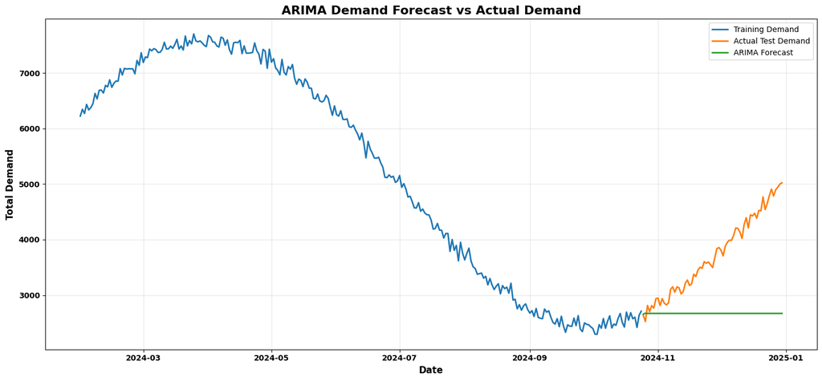

```python
# ARIMA Forecast Visualization

# CELL 8 — ACTUAL vs ARIMA FORECAST

plt.figure(figsize=(15, 7))

# Training demand
plt.plot(
    train["Date"],
    train["Total_Demand"],
    label="Training Demand",
    linewidth=2
)

# Actual test demand
plt.plot(
    test["Date"],
    test["Total_Demand"],
    label="Actual Test Demand",
    linewidth=2
)

# ARIMA forecast
plt.plot(
    arima_forecast_df["Date"],
    arima_forecast_df["ARIMA_Forecast"],
    label="ARIMA Forecast",
    linewidth=2
)

plt.title(
    "ARIMA Demand Forecast vs Actual Demand",
    fontsize=16,
    fontweight="bold"
)

plt.xlabel(
    "Date",
    fontsize=12,
    fontweight="bold"
)

plt.ylabel(
    "Total Demand",
    fontsize=12,
    fontweight="bold"
)

plt.xticks(fontweight="bold")
plt.yticks(fontweight="bold")

plt.grid(alpha=0.3)
plt.legend()

plt.tight_layout()
plt.show()
```

```python
# ARIMA Evaluation
from sklearn.metrics import mean_absolute_error, mean_squared_error
import numpy as np

arima_mae = mean_absolute_error(
    arima_forecast_df["Total_Demand"],
    arima_forecast_df["ARIMA_Forecast"]
)

arima_rmse = np.sqrt(
    mean_squared_error(
        arima_forecast_df["Total_Demand"],
        arima_forecast_df["ARIMA_Forecast"]
    )
)

arima_mape = np.mean(
    np.abs(
        (arima_forecast_df["Total_Demand"] -
         arima_forecast_df["ARIMA_Forecast"])
        / arima_forecast_df["Total_Demand"]
    )
) * 100

print("ARIMA Model Evaluation")
print("=" * 55)
print(f"MAE  : {arima_mae:.2f}")
print(f"RMSE : {arima_rmse:.2f}")
print(f"MAPE : {arima_mape:.2f}%")
```

```
ARIMA Model Evaluation
=======================================================
MAE  : 1053.89
RMSE : 1264.51
MAPE : 25.74%
```

```python
# Baseline vs ARIMA Comparison
comparison_df = pd.DataFrame({
    "Model": [
        "7-Day Moving Average",
        "30-Day Moving Average",
        "ARIMA(1,1,1)"
    ],
    "MAE": [
        147.29,
        476.63,
        arima_mae
    ],
    "RMSE": [
        169.11,
        505.14,
        arima_rmse
    ],
    "MAPE (%)": [
        3.93,
        12.47,
        arima_mape
    ]
})

comparison_df = comparison_df.sort_values("RMSE").reset_index(drop=True)

print("Forecasting Model Comparison")
print("=" * 70)
display(comparison_df)

best_model = comparison_df.loc[0, "Model"]

print("\nBest Forecasting Model :", best_model)
print("Lowest RMSE            :", f"{comparison_df.loc[0, 'RMSE']:.2f}")
```

```
Forecasting Model Comparison
======================================================================
```

|  | Model | MAE | RMSE | MAPE (%) |
| --- | --- | --- | --- | --- |
| 0 | 7-Day Moving Average | 147.290000 | 169.110000 | 3.930000 |
| 1 | 30-Day Moving Average | 476.630000 | 505.140000 | 12.470000 |
| 2 | ARIMA(1,1,1) | 1053.891914 | 1264.509729 | 25.740297 |

```
Best Forecasting Model : 7-Day Moving Average
Lowest RMSE            : 169.11
```

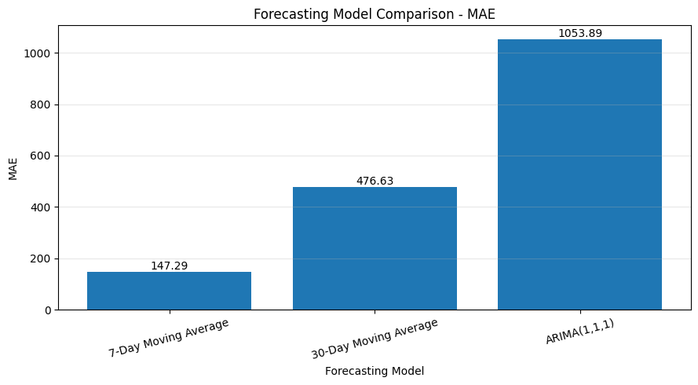

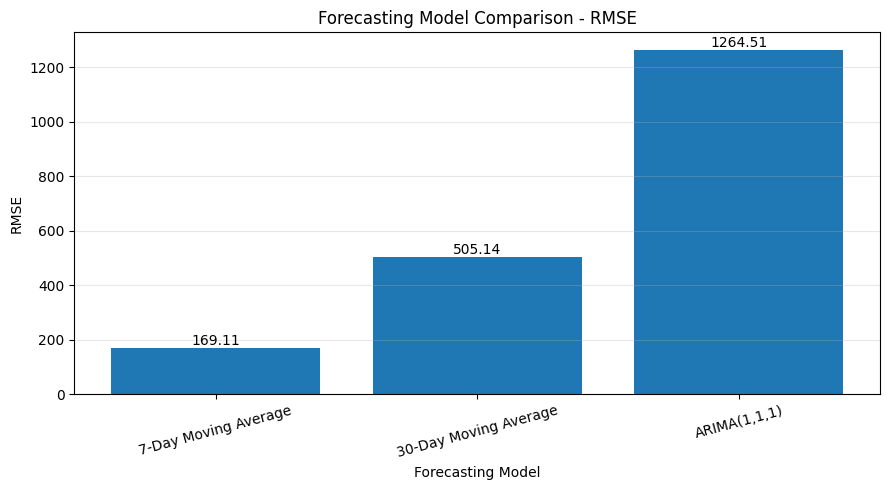

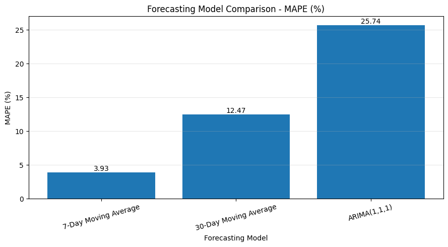

```python
# Model Performance Visualization
import matplotlib.pyplot as plt

metrics_to_plot = ["MAE", "RMSE", "MAPE (%)"]

for metric in metrics_to_plot:
    plt.figure(figsize=(9, 5))

    bars = plt.bar(
        comparison_df["Model"],
        comparison_df[metric]
    )

    plt.title(f"Forecasting Model Comparison - {metric}")
    plt.xlabel("Forecasting Model")
    plt.ylabel(metric)
    plt.xticks(rotation=15)
    plt.grid(axis="y", alpha=0.3)

    # Different value labels for each bar
    for bar in bars:
        height = bar.get_height()
        plt.text(
            bar.get_x() + bar.get_width() / 2,
            height,
            f"{height:.2f}",
            ha="center",
            va="bottom"
        )

    plt.tight_layout()
    plt.show()
```

```python
# Final Forecasting Summary

best_row = comparison_df.iloc[0]

print("FINAL FORECASTING MODEL SUMMARY")
print("=" * 60)

print(f"Best Model : {best_row['Model']}")
print(f"MAE        : {best_row['MAE']:.2f}")
print(f"RMSE       : {best_row['RMSE']:.2f}")
print(f"MAPE       : {best_row['MAPE (%)']:.2f}%")

print("\nModel Selection Criteria:")
print("Lower MAE, RMSE and MAPE indicate better forecasting performance.")

print("\nBaseline Performance:")
print(f"7-Day Moving Average RMSE : 169.11")
print(f"30-Day Moving Average RMSE: 505.14")

print("\nARIMA Performance:")
print(f"ARIMA(1,1,1) RMSE         : {arima_rmse:.2f}")

print("\nFinal Decision:")
print(
    f"{best_row['Model']} is selected as the best-performing "
    "forecasting model based on the lowest RMSE."
)
```

```
FINAL FORECASTING MODEL SUMMARY
============================================================
Best Model : 7-Day Moving Average
MAE        : 147.29
RMSE       : 169.11
MAPE       : 3.93%

Model Selection Criteria:
Lower MAE, RMSE and MAPE indicate better forecasting performance.

Baseline Performance:
7-Day Moving Average RMSE : 169.11
30-Day Moving Average RMSE: 505.14

ARIMA Performance:
ARIMA(1,1,1) RMSE         : 1264.51

Final Decision:
7-Day Moving Average is selected as the best-performing forecasting model based on the lowest RMSE.
```

```python
# Next 90 Days Forecast

# generate 90-day demand forecast

# get last 7 historical demand values
recent_demand = daily_demand["Total_Demand"].tail(7).tolist()

# generate recursive 7-day moving average forecast
forecast_90_days = []

for _ in range(90):
    next_forecast = np.mean(recent_demand[-7:])
    forecast_90_days.append(next_forecast)
    recent_demand.append(next_forecast)

# create future dates
last_date = daily_demand["Date"].max()

future_dates = pd.date_range(
    start=last_date + pd.Timedelta(days=1),
    periods=90,
    freq="D"
)

# create forecast dataframe
future_forecast_df = pd.DataFrame({
    "Date": future_dates,
    "Forecasted_Demand": forecast_90_days
})

print("90-Day Demand Forecast Generated Successfully")
print("=" * 60)

print("Forecast Horizon :", len(future_forecast_df))
print("Expected Horizon :", 90)

print("\nForecast Date Range:")
print("Start :", future_forecast_df["Date"].min())
print("End   :", future_forecast_df["Date"].max())

print("\nForecast Summary:")
print(future_forecast_df["Forecasted_Demand"].describe())

print("\nForecast Sample:")
display(future_forecast_df.head(10))
```

```
90-Day Demand Forecast Generated Successfully
============================================================
Forecast Horizon : 90
Expected Horizon : 90

Forecast Date Range:
Start : 2024-12-31 00:00:00
End   : 2025-03-30 00:00:00

Forecast Summary:
count      90.000000
mean     4943.109127
std         5.139227
min      4906.857143
25%      4943.785560
50%      4943.785714
75%      4943.785779
max      4953.758723
Name: Forecasted_Demand, dtype: float64

Forecast Sample:
```

|  | Date | Forecasted_Demand |
| --- | --- | --- |
| 0 | 2024-12-31 | 4906.857143 |
| 1 | 2025-01-01 | 4923.265306 |
| 2 | 2025-01-02 | 4925.303207 |
| 3 | 2025-01-03 | 4945.346522 |
| 4 | 2025-01-04 | 4952.538883 |
| 5 | 2025-01-05 | 4953.758723 |
| 6 | 2025-01-06 | 4947.152826 |
| 7 | 2025-01-07 | 4936.317516 |
| 8 | 2025-01-08 | 4940.526140 |
| 9 | 2025-01-09 | 4942.991974 |

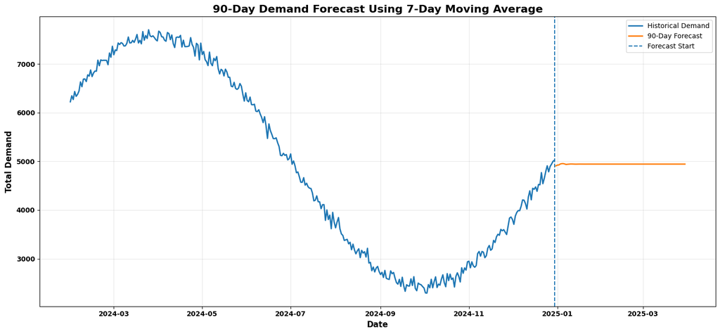

```python
# visualize 90-day demand forecast

plt.figure(figsize=(15, 7))

plt.plot(
    daily_demand["Date"],
    daily_demand["Total_Demand"],
    label="Historical Demand",
    linewidth=2
)

plt.plot(
    future_forecast_df["Date"],
    future_forecast_df["Forecasted_Demand"],
    label="90-Day Forecast",
    linewidth=2
)

plt.axvline(
    daily_demand["Date"].max(),
    linestyle="--",
    linewidth=1.5,
    label="Forecast Start"
)

plt.title(
    "90-Day Demand Forecast Using 7-Day Moving Average",
    fontsize=16,
    fontweight="bold"
)

plt.xlabel(
    "Date",
    fontsize=12,
    fontweight="bold"
)

plt.ylabel(
    "Total Demand",
    fontsize=12,
    fontweight="bold"
)

plt.xticks(fontweight="bold")
plt.yticks(fontweight="bold")

plt.grid(alpha=0.3)
plt.legend()

plt.tight_layout()
plt.show()
```

```python
# 90-Day Forecast Insights
# analyze 90-day forecast

avg_forecast = future_forecast_df["Forecasted_Demand"].mean()
min_forecast = future_forecast_df["Forecasted_Demand"].min()
max_forecast = future_forecast_df["Forecasted_Demand"].max()

first_7_days_avg = future_forecast_df["Forecasted_Demand"].head(7).mean()
last_7_days_avg = future_forecast_df["Forecasted_Demand"].tail(7).mean()

forecast_change = last_7_days_avg - first_7_days_avg

print("90-DAY FORECAST INSIGHTS")
print("=" * 60)

print(f"Average Forecasted Demand : {avg_forecast:.2f}")
print(f"Minimum Forecasted Demand : {min_forecast:.2f}")
print(f"Maximum Forecasted Demand : {max_forecast:.2f}")

print(f"\nFirst 7-Day Average       : {first_7_days_avg:.2f}")
print(f"Last 7-Day Average        : {last_7_days_avg:.2f}")
print(f"Forecast Change            : {forecast_change:.2f}")

print("\nBusiness Interpretation:")

if abs(forecast_change) < avg_forecast * 0.02:
    print("Demand is expected to remain relatively stable over the forecast horizon.")
elif forecast_change > 0:
    print("Demand shows an increasing trend over the forecast horizon.")
else:
    print("Demand shows a decreasing trend over the forecast horizon.")
```

```
90-DAY FORECAST INSIGHTS
============================================================
Average Forecasted Demand : 4943.11
Minimum Forecasted Demand : 4906.86
Maximum Forecasted Demand : 4953.76

First 7-Day Average       : 4936.32
Last 7-Day Average        : 4943.79
Forecast Change            : 7.47

Business Interpretation:
Demand is expected to remain relatively stable over the forecast horizon.
```

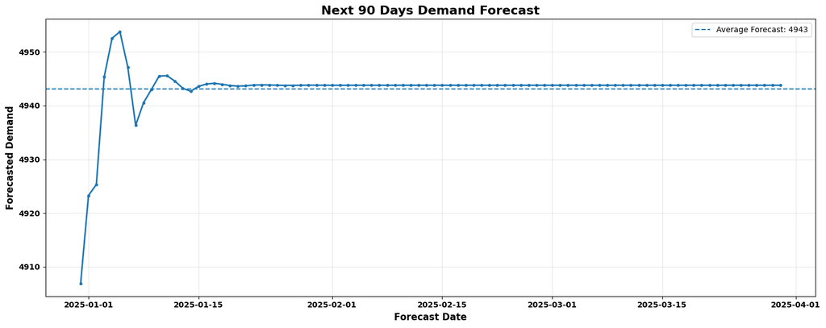

```python
# Focused 90-Day Forecast Visualization
# visualize future demand forecast

plt.figure(figsize=(15, 6))

plt.plot(
    future_forecast_df["Date"],
    future_forecast_df["Forecasted_Demand"],
    marker="o",
    markersize=3,
    linewidth=2
)

plt.axhline(
    avg_forecast,
    linestyle="--",
    linewidth=1.5,
    label=f"Average Forecast: {avg_forecast:.0f}"
)

plt.title(
    "Next 90 Days Demand Forecast",
    fontsize=16,
    fontweight="bold"
)

plt.xlabel(
    "Forecast Date",
    fontsize=12,
    fontweight="bold"
)

plt.ylabel(
    "Forecasted Demand",
    fontsize=12,
    fontweight="bold"
)

plt.xticks(fontweight="bold")
plt.yticks(fontweight="bold")

plt.grid(alpha=0.3)
plt.legend()

plt.tight_layout()
plt.show()
```

```python
# validate and save final forecast

print("FINAL FORECAST VALIDATION")
print("=" * 60)

print("Forecast Rows        :", len(future_forecast_df))
print("Expected Rows        :", 90)

print("\nMissing Values       :", future_forecast_df.isnull().sum().sum())
print("Duplicate Rows       :", future_forecast_df.duplicated().sum())

print("\nForecast Date Range:")
print("Start                :", future_forecast_df["Date"].min())
print("End                  :", future_forecast_df["Date"].max())

print("\nForecast Value Check:")
print("Minimum Forecast     :", future_forecast_df["Forecasted_Demand"].min())
print("Maximum Forecast     :", future_forecast_df["Forecasted_Demand"].max())

# save final forecast
forecast_path = r"C:\Users\LENOVO\Desktop\Supply-Chain-Demand-Forecasting-Anomaly-Detection\data\processed\90_day_demand_forecast.csv"

future_forecast_df.to_csv(
    forecast_path,
    index=False
)

print("\nFinal 90-Day Forecast Saved Successfully")
print("Saved Path           :", forecast_path)
```

```
FINAL FORECAST VALIDATION
============================================================
Forecast Rows        : 90
Expected Rows        : 90

Missing Values       : 0
Duplicate Rows       : 0

Forecast Date Range:
Start                : 2024-12-31 00:00:00
End                  : 2025-03-30 00:00:00

Forecast Value Check:
Minimum Forecast     : 4906.857142857143
Maximum Forecast     : 4953.7587229810715

Final 90-Day Forecast Saved Successfully
Saved Path           : C:\Users\LENOVO\Desktop\Supply-Chain-Demand-Forecasting-Anomaly-Detection\data\processed\90_day_demand_forecast.csv
```

# Demand Forecasting & Model Evaluation

## Objective

The objective of this phase was to build and evaluate demand forecasting models using the feature-engineered supply chain dataset and select the best-performing model based on forecasting accuracy metrics.

## Work Completed

### 1. Feature-Engineered Dataset Loading

- Loaded the final feature-engineered dataset.
- Dataset Shape: 83,750 rows × 33 columns.
- Date Range: 31-Jan-2024 to 30-Dec-2024.
- Verified missing values and duplicate records.

### 2. Daily Demand Aggregation

- Aggregated `Units_Sold` at daily level to create `Total_Demand`.
- Created a daily demand time series containing 335 observations.

### 3. Chronological Train-Test Split

- Applied a time-based train-test split to avoid data leakage.
- Training Set: 268 observations.
- Testing Set: 67 observations.
- Train Period: 31-Jan-2024 to 24-Oct-2024.
- Test Period: 25-Oct-2024 to 30-Dec-2024.
- Verified that there was no date overlap.

### 4. Baseline Forecasting

Two Moving Average forecasting models were developed:

- 7-Day Moving Average
- 30-Day Moving Average

Model evaluation:

| Model | MAE | RMSE | MAPE |
| --- | --- | --- | --- |
| 7-Day Moving Average | 147.29 | 169.11 | 3.93% |
| 30-Day Moving Average | 476.63 | 505.14 | 12.47% |

The 7-Day Moving Average was selected as the best baseline model.

### 5. ARIMA Forecasting

- Developed an ARIMA(1,1,1) model.
- Training observations: 268.
- Generated forecasts for the complete 67-day test period.
- Evaluated ARIMA using MAE, RMSE and MAPE.

ARIMA Performance:

- MAE: 1053.89
- RMSE: 1264.51
- MAPE: 25.74%

### 6. Forecasting Model Comparison

All forecasting models were compared using the same test dataset.

| Model | MAE | RMSE | MAPE |
| --- | --- | --- | --- |
| 7-Day Moving Average | 147.29 | 169.11 | 3.93% |
| 30-Day Moving Average | 476.63 | 505.14 | 12.47% |
| ARIMA(1,1,1) | 1053.89 | 1264.51 | 25.74% |

### Final Model Selection

The **7-Day Moving Average** was selected as the best forecasting model because it achieved the lowest RMSE, MAE and MAPE.

### 7. 90-Day Demand Forecast

Using the selected 7-Day Moving Average model, a recursive 90-day demand forecast was generated.

Forecast Period:

- Start: 31-Dec-2024
- End: 30-Mar-2025
- Forecast Horizon: 90 days

Forecast Insights:

- Average Forecasted Demand: 4,943.11 units/day
- Minimum Forecast: 4,906.86 units/day
- Maximum Forecast: 4,953.76 units/day
- First 7-Day Average: 4,936.32
- Last 7-Day Average: 4,943.79

The forecast indicates relatively stable demand over the next 90 days.

### 8. Forecast Validation & Output

- Forecast Rows: 90
- Missing Values: 0
- Duplicate Rows: 0
- Final 90-day forecast was successfully saved as a processed CSV file.

## Key Business Insight

The 7-Day Moving Average provided the most accurate demand forecasts for this dataset, outperforming both the 30-Day Moving Average and ARIMA(1,1,1). The 90-day forecast indicates relatively stable future demand, which can support inventory planning, procurement decisions and supply chain resource allocation.